# Projet Analyse de Donnée

# 3 Analyse des Correspondances Multiples (ACM)

**Extraction des données**

```r
binary_data <- data %>%
  select(starts_with("Personal")) %>%
  na.omit()

# Show the first few rows
#head(binary_data)
```

**Encodage des questions**

```r
print(sub("^.*\\.\\.\\.", "", colnames(binary_data)))
```

```
##  [1] "Have.you.ever.rewatched.these.series.."
##  [2] ""
##  [3] "Did.these.series.introduce.you.to.new.ideas.or.cultures.."
##  [4] "Do.you.feel.emotionally.attached.to.the.characters.in.these.series.."
##  [5] "Did.you.experience.a.sense.of.loss.or.sadness.when.the.series.ended.."
##  [6] ""
##  [7] "Have.you.referenced.certain.series.in.conversations.or.jokes.."
##  [8] "Were.series.a.factor.in.bonding.with.someone.."
##  [9] "Did.series.negatively.affect.your.mood.or.emotions.."
## [10] "Did.you.find.series.not.predictable.in.its.storyline.."
```

```r
colnames(binary_data) <- paste0("q", 1:ncol(binary_data))
head(binary_data)
```

```
##    q1  q2  q3  q4  q5  q6  q7  q8  q9 q10
## 1 Yes Yes Yes Yes Yes  No Yes Yes  No  No
## 2 Yes  No Yes Yes Yes Yes Yes Yes Yes Yes
## 3 Yes Yes Yes Yes Yes Yes Yes Yes  No Yes
## 4  No  No Yes  No  No Yes  No Yes Yes  No
## 5 Yes Yes  No Yes Yes  No Yes Yes Yes  No
## 6  No Yes      No Yes     Yes     Yes Yes
```

**Effectuer l’ACM**

```r
res.mca <- MCA (binary_data, graph = FALSE)
res.mca$eig
```

```
##          eigenvalue percentage of variance cumulative percentage of variance
## dim 1  8.976840e-01           4.488420e+01                          44.88420
## dim 2  1.765015e-01           8.825074e+00                          53.70927
## dim 3  1.685454e-01           8.427269e+00                          62.13654
## dim 4  1.451214e-01           7.256071e+00                          69.39261
## dim 5  1.142916e-01           5.714579e+00                          75.10719
## dim 6  9.293099e-02           4.646549e+00                          79.75374
## dim 7  9.020688e-02           4.510344e+00                          84.26409
## dim 8  7.892600e-02           3.946300e+00                          88.21039
## dim 9  6.907612e-02           3.453806e+00                          91.66419
## dim 10 5.621402e-02           2.810701e+00                          94.47489
## dim 11 4.733845e-02           2.366923e+00                          96.84182
## dim 12 3.554536e-02           1.777268e+00                          98.61908
## dim 13 2.065023e-02           1.032511e+00                          99.65159
## dim 14 6.968101e-03           3.484050e-01                         100.00000
## dim 15 5.057739e-31           2.528869e-29                         100.00000
## dim 16 8.278546e-32           4.139273e-30                         100.00000
## dim 17 4.400370e-32           2.200185e-30                         100.00000
## dim 18 2.138390e-32           1.069195e-30                         100.00000
## dim 19 7.828988e-33           3.914494e-31                         100.00000
## dim 20 7.828988e-33           3.914494e-31                         100.00000
```

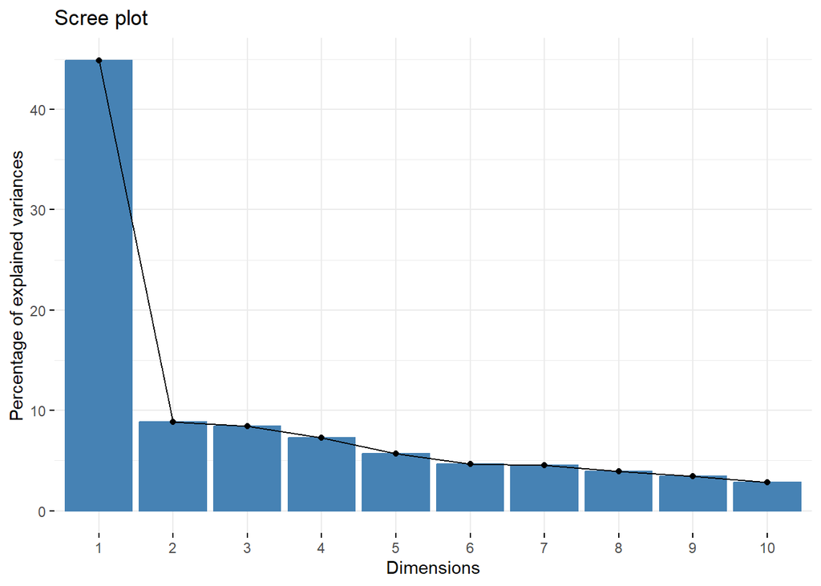

```r
fviz_screeplot(res.mca)
```

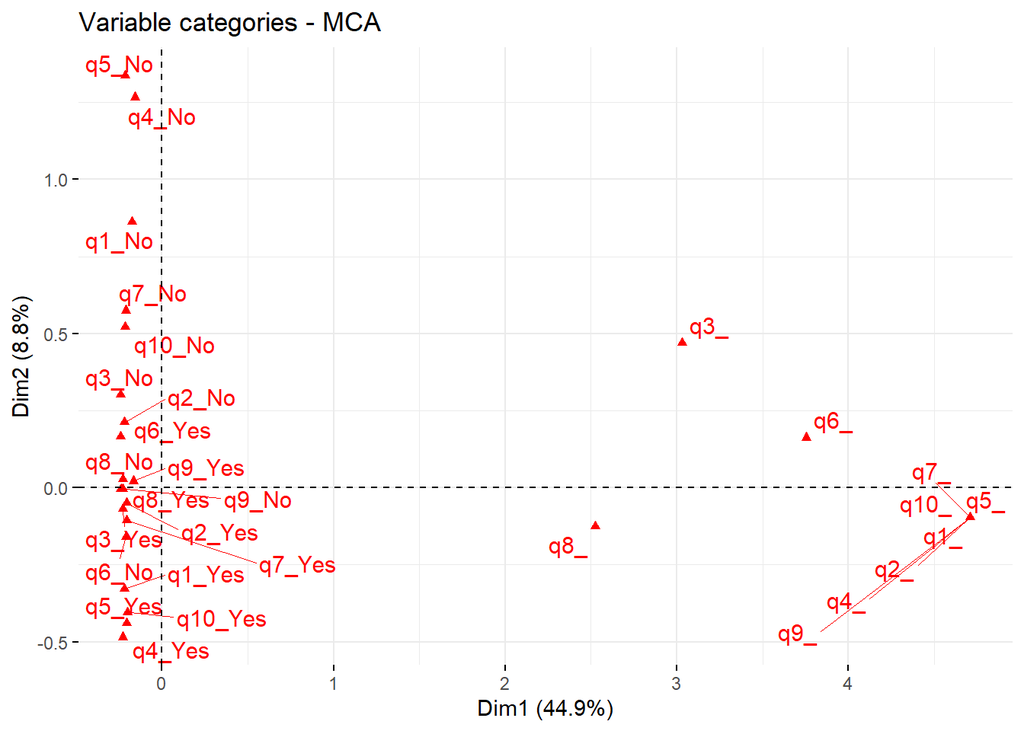

```r
fviz_mca_var (res.mca,
              repel = TRUE,
              ggtheme = theme_minimal ())
```

**Interprétation**

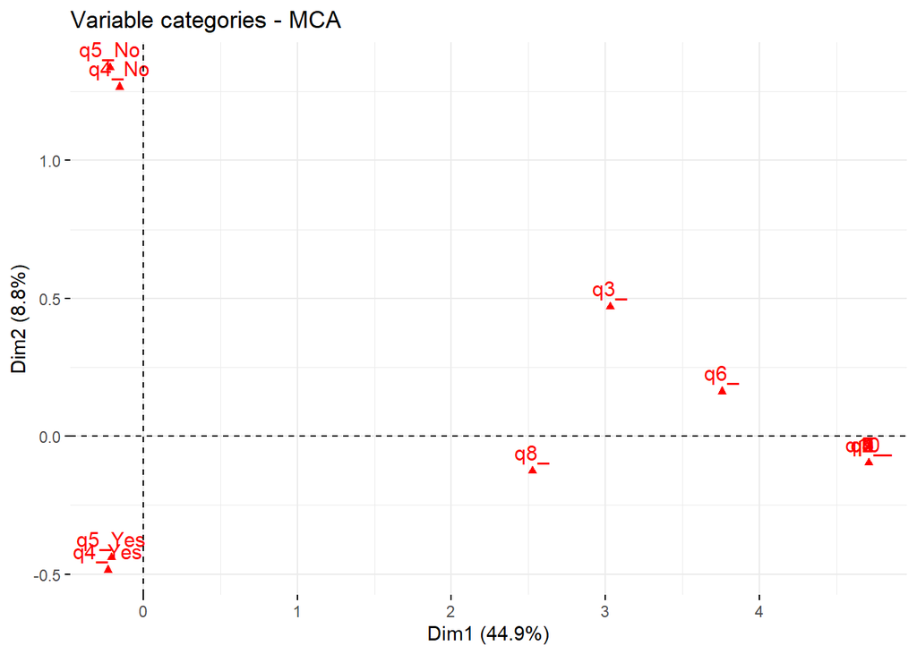

```r
fviz_mca_var(res.mca, select.var = list(cos2 = 0.4))
```

# 4 Analyse Factorielle des Correspondances (AFC) :

Cette partie sert à trouver des coorélation entre Profession (occupation) eg..étudiant,fonctionnaire,élève et Raison de regarder les séries (eg. chill , relax , plot)

**Extraction des données**

```r
# Load necessary library
library(dplyr)

# Assuming 'your_dataframe' is the name of your original dataframe
data_afc <- data.frame(
  occupation = data %>%
    select(starts_with("What.is.your.current")) %>%
    na.omit() %>%
    pull(),  # Use pull() to extract the column as a vector
  primary_reason = data %>%
    select(starts_with("Primary.reason")) %>%
    na.omit() %>%
    pull()  # Use pull() to extract the column as a vector
)
head(data_afc)
```

```
##           occupation  primary_reason
## 1 University student To relax/unwind
## 2 University student   The storyline
## 3 University student  The characters
## 4           Employed   The storyline
## 5         Unemployed   The storyline
## 6 University student   The storyline
```

## 4.1 Tableau de contingence :

```r
contingency_table <- table(data_afc$occupation, data_afc$primary_reason)
addmargins(contingency_table)
```

```
##
##                       Because it's trending The characters The storyline
##   Employed                                0              0             3
##   High school student                     0              2             9
##   Unemployed                              0              0             1
##   University student                      1              6            28
##   Sum                                     1              8            41
##
##                       The visuals/production quality To relax/unwind Sum
##   Employed                                         0               4   7
##   High school student                              0               0  11
##   Unemployed                                       0               0   1
##   University student                               6              11  52
##   Sum                                              6              15  71
```

**Profil lignes**

```r
library(questionr)
lprop(contingency_table)
```

```
##
##                       Because it's trending The characters The storyline
##   Employed              0.0                   0.0           42.9
##   High school student   0.0                  18.2           81.8
##   Unemployed            0.0                   0.0          100.0
##   University student    1.9                  11.5           53.8
##   Ensemble              1.4                  11.3           57.7
##
##                       The visuals/production quality To relax/unwind Total
##   Employed              0.0                           57.1           100.0
##   High school student   0.0                            0.0           100.0
##   Unemployed            0.0                            0.0           100.0
##   University student   11.5                           21.2           100.0
##   Ensemble              8.5                           21.1           100.0
```

**Interprétation** 0% des employés regardent une série parce qu’elle est tendance, la majorité le fait pour se détendre, tandis que 81% des lycéens regardent les séries pour leur intrigue.

**Profils Colonnes**

```r
cprop(contingency_table)
```

```
##
##                       Because it's trending The characters The storyline
##   Employed              0.0                   0.0            7.3
##   High school student   0.0                  25.0           22.0
##   Unemployed            0.0                   0.0            2.4
##   University student  100.0                  75.0           68.3
##   Total               100.0                 100.0          100.0
##
##                       The visuals/production quality To relax/unwind Ensemble
##   Employed              0.0                           26.7             9.9
##   High school student   0.0                            0.0            15.5
##   Unemployed            0.0                            0.0             1.4
##   University student  100.0                           73.3            73.2
##   Total               100.0                          100.0           100.0
```

**Interprétation**

Pour la catégorie ‘The storyline’, elle est composée de 7% des employés, 22% des lycéens, 2% des chômeurs et 68% des étudiants.

## 4.2 Test KH 2 :

```r
test<-chisq.test(contingency_table)
test
```

```
##
##  Pearson's Chi-squared test
##
## data:  contingency_table
## X-squared = 12.581, df = 12, p-value = 0.4002
```

**Interprétation**

Puisque 0.4 > 0.05, on retient H₀ et on conclut qu’il n’y a pas de preuve statistique d’une dépendance significative entre les variables.

La pertinance de cette AFC est donc faible !

L’inertie totale est χ2/n = 12.581/71 = 0,17719

**Effectuer l’AFC**

```r
library(FactoMineR)

res.ca<-CA(contingency_table,graph=F)
summary(res.ca)
```

```
##
## Call:
## CA(X = contingency_table, graph = F)
##
## The chi square of independence between the two variables is equal to 12.58102 (p-value =  0.4002147 ).
##
## Eigenvalues
##                        Dim.1   Dim.2   Dim.3
## Variance               0.130   0.043   0.004
## % of var.             73.645  24.047   2.308
## Cumulative % of var.  73.645  97.692 100.000
##
## Rows
##                                  Iner*1000    Dim.1    ctr   cos2    Dim.2
## Employed                       |    85.148 |  0.841 53.442  0.819 | -0.395
## High school student            |    70.126 | -0.604 43.382  0.807 | -0.291
## Unemployed                     |    10.306 | -0.513  2.838  0.359 | -0.459
## University student             |    11.618 |  0.025  0.337  0.038 |  0.123
##                                   ctr   cos2    Dim.3    ctr   cos2
## Employed                       36.102  0.181 |  0.016  0.597  0.000 |
## High school student            30.714  0.187 |  0.052 10.411  0.006 |
## Unemployed                      6.973  0.288 | -0.508 88.780  0.352 |
## University student             26.211  0.961 | -0.003  0.212  0.001 |
##
## Columns
##                                  Iner*1000    Dim.1    ctr   cos2    Dim.2
## Because it's trending          |     5.146 |  0.068  0.050  0.013 |  0.598
## The characters                 |    19.317 | -0.367 11.658  0.788 |  0.097
## The storyline                  |    25.615 | -0.185 15.184  0.774 | -0.095
## The visuals/production quality |    30.878 |  0.068  0.298  0.013 |  0.598
## To relax/unwind                |    96.242 |  0.671 72.810  0.987 | -0.072
##                                   ctr   cos2    Dim.3    ctr   cos2
## Because it's trending          11.829  0.979 | -0.054  0.998  0.008 |
## The characters                  2.471  0.055 |  0.165 74.603  0.158 |
## The storyline                  12.182  0.203 | -0.032 14.887  0.024 |
## The visuals/production quality 70.976  0.979 | -0.054  5.989  0.008 |
## To relax/unwind                 2.541  0.011 |  0.026  3.523  0.001 |
```

```r
eig.val <- res.ca$eig
round(res.ca$eig,3)
```

```
##       eigenvalue percentage of variance cumulative percentage of variance
## dim 1      0.130                 73.645                            73.645
## dim 2      0.043                 24.047                            97.692
## dim 3      0.004                  2.308                           100.000
```

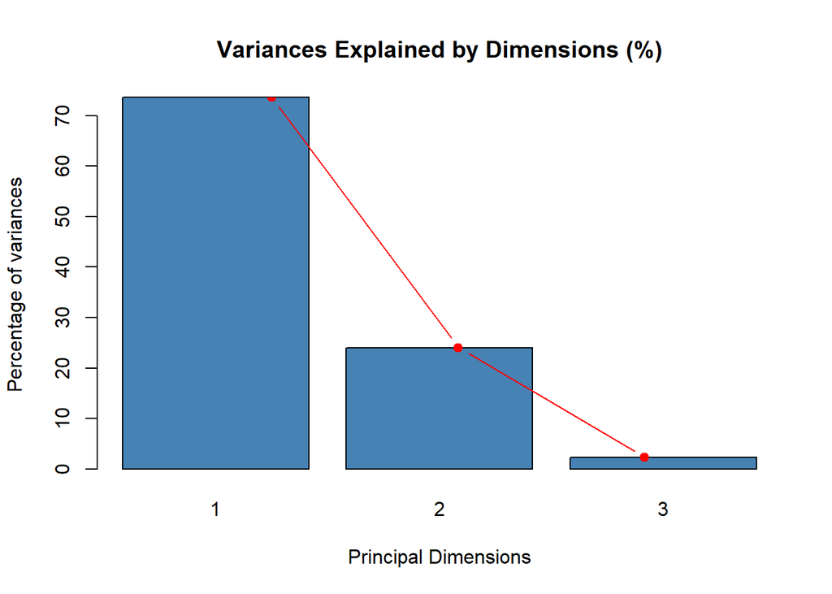

```r
barplot(eig.val[, 2],
        names.arg = 1:nrow(eig.val),
        main = "Variances Explained by Dimensions (%)",
        xlab = "Principal Dimensions",
        ylab = "Percentage of variances",
        col ="steelblue")
# Add connected line segments to the plot
lines(x = 1:nrow(eig.val), eig.val[, 2],
      type = "b", pch = 19, col = "red")
```

## 4.3 carte profile-colonnes:

```r
round(cbind(res.ca$col$coord[,1:2],res.ca$col$contrib[,1:2], res.ca$col$cos2[,1:2]),2)
```

```
##                                Dim 1 Dim 2 Dim 1 Dim 2 Dim 1 Dim 2
## Because it's trending           0.07  0.60  0.05 11.83  0.01  0.98
## The characters                 -0.37  0.10 11.66  2.47  0.79  0.05
## The storyline                  -0.19 -0.09 15.18 12.18  0.77  0.20
## The visuals/production quality  0.07  0.60  0.30 70.98  0.01  0.98
## To relax/unwind                 0.67 -0.07 72.81  2.54  0.99  0.01
```

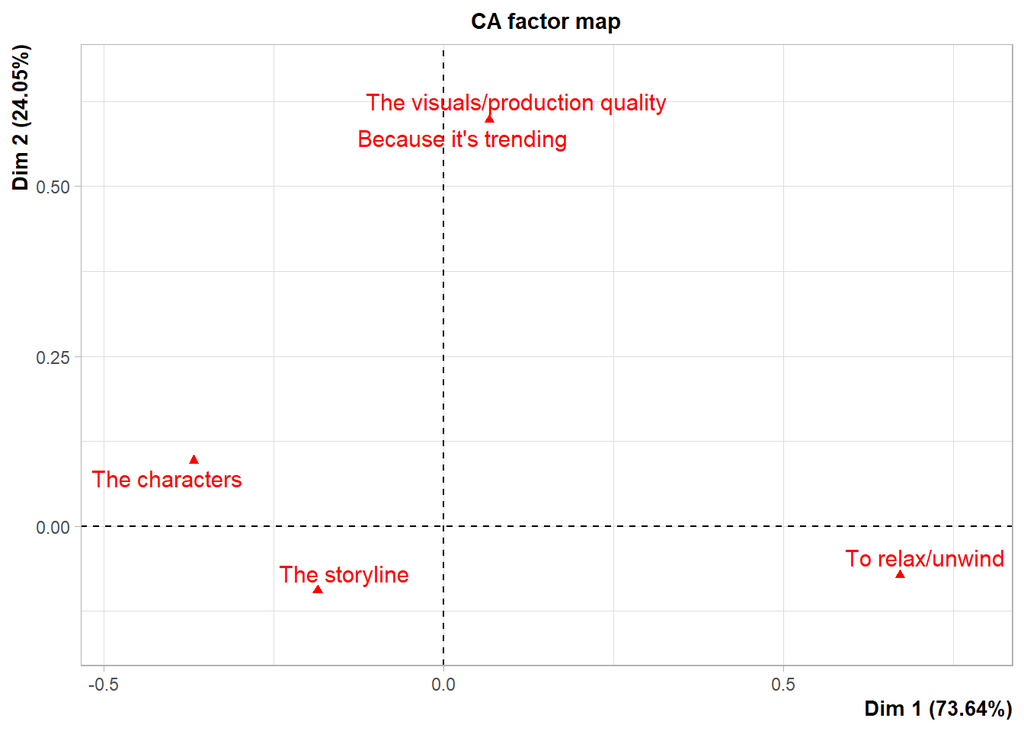

```r
plot(res.ca, invisible="row")
```

Les catégories professionnelles qui regardent les séries télévisées pour les personnages et l’intrigue ont le même profil. Elles s’opposent à ceux qui regardent les séries pour se détendre. Cependant, il y a une forte ressemblance entre les profils qui regardent pour la tendance et la qualité visuelle.

## 4.4 carte profile ligne :

```r
round(cbind(res.ca$row$coord[,1:2],res.ca$row$contrib[,1:2], res.ca$row$cos2[,1:2]),2)
```

```
##                     Dim 1 Dim 2 Dim 1 Dim 2 Dim 1 Dim 2
## Employed             0.84 -0.40 53.44 36.10  0.82  0.18
## High school student -0.60 -0.29 43.38 30.71  0.81  0.19
## Unemployed          -0.51 -0.46  2.84  6.97  0.36  0.29
## University student   0.02  0.12  0.34 26.21  0.04  0.96
```

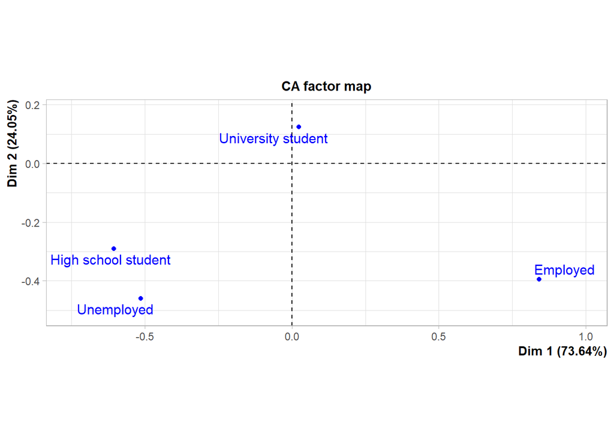

```r
plot(res.ca, invisible="col")
```

**Interprétation**:

On trouve une ressemblance entre les lycéens et les chômeurs ; ces deux derniers sont opposés au profil des employés dans les raisons qui les poussent à regarder les séries.

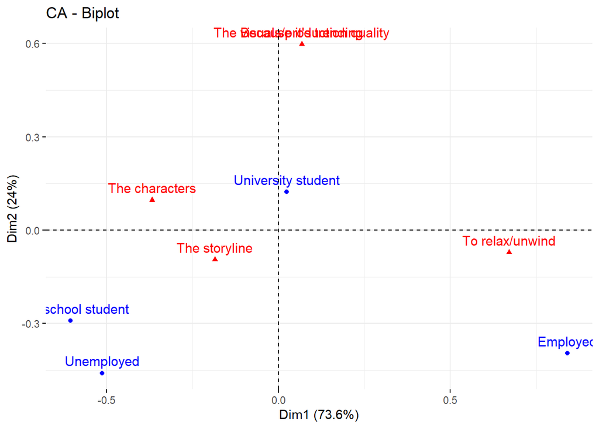

```r
library(factoextra)

fviz_ca_biplot(res.ca)
```

**Interprétation** :

**Employed et To relax/unwind proches** :

Employed (fortement associé à Dim 1) est proche de To relax/unwind, suggérant que les employés privilégient la détente comme motivation principale.

**University Student aligné avec “The visuals/production quality”** :

University Student est fortement lié à The visuals/production quality sur Dim 2, montrant que les étudiants universitaires accordent une grande importance à la qualité visuelle.

**Opposition entre High School Student et Employed** :

High School Student et Employed sont opposés sur Dim 1, indiquant des motivations différentes : les lycéens sont plus intéressés par The characters et The storyline, tandis que les employés cherchent à se détendre.

# 5 Conclusion:

Ce projet a abordé les différents aspects statistiques étudiés en cours : **ACP** (Analyse en Composantes Principales), **AFC** (Analyse Factorielle des Correspondances) et **ACM** (Analyse des Correspondances Multiples) afin d’extraire des connaissances à partir d’une base de données.

Enfin, une AFC a été réalisée afin de distinguer la **relation entre les spectateurs et leurs raisons de regarder des séries télévisées**.

Toutes ces analyses **ont été accompagnées d’une interprétation des résultats visuels**.

En conclusion, nous pouvons affirmer que l’objectif initial du projet a été atteint.